# MPhil Thesis: HT Week 1

Mohammad-Shah Karim

2025-01-26

# Recap

- FDA and Patent data sorted
- Regressions ran for two research questions
  - Effect of ACA on innovation overall
  - Effect of ACA on innovation portfolio
- Failure of parallel trends
- No PDL data
- No price restriction data
- No theoretical model

# Tidying issues from Michaelmas

## Failure of parallel trends

- Fixed patent calculatioins
- Parallel trends for all FEOLS specifications
- Violation of parallel trends under NB patent specifications

# The Preferred Drug list

# A quick reintroduction

- Each state has their own PDL
- Some states form a pool to negotiate better prices

The problem:

- Some PDLs are in pdf format e.g. California
- Some PDLs only show the most recent list e.g. New York

Proposed solution:

- Use Texas Drug Vendor data files

## The General PDL Mechanism revisited

A drug becomes preferred when it is clinically acceptable **and** offers the lowest net cost among substitutes.

1. P&T committee evaluates safety, efficacy and literature on drug.
2. States compare net price among clinically equivalent drugs, with price determining which eligible drugs become most preferred.

```
flowchart LR

A["Clinical Review<br/> (P&T Committee)"] -->|Clinically acceptable| B["Economic Evaluation<br/> (Rebate Negotiation)"]
A -->|Clinically inappropriate| X["Ineligible<br/> (Cannot be preferred)"]

B --> C{"Net cost comparison<br/> among clinically equivalent drugs"}

C -->|Lowest net cost| D["Preferred Drug"]
C -->|Higher net cost| E["Non-preferred Drug<br/> (Authorisation required for use)"]
```

States can list multiple preferred drugs when they are not clinically equivalent.

# Is the mechanism the same in Texas?

Yes but no!

- Both stage 1 and stage 2 must be passed.
- But stage 1 and stage 2 are **not** sequential - they occur simultaenously

This dataset now gives us four scenarios that can be used accordingly:

| Pass efficacy / safety test | Pass cost test | Group |
| --- | --- | --- |
| ❌ | ❌ | N/A |
| ❌ | ✅ | Control to measure impact of being cheap on innovation |
| ✅ | ❌ | Control to measure impact of having efficacy on innovation |
| ✅ | ✅ | Treated group |

# Research Questions

## RQ1: Overall innovation response to Market size

$$\begin{aligned}
Y_{f,c,t}
= \alpha_{f, c} + \delta_t
+ \sum_{k \neq 2013}^{2025} \beta_k \left[ \mathbf{1}\{t = k\} \times \text{MedicaidShare}_c \right]
+ \varepsilon_{f,c,t}
\end{aligned}$$

- Changed disease-FE to disease $\times$ firm FE
- Firms have different innovation volumes so firm FE makes sense.
- Some therapeutic areas have different innovation volumes.

## Pre-discussion

- Violation of parallel trends for negative binomial model patents model
- Conclusion still consistent with last time
  - No effect on FDA approvals (late stage innovation)
  - Reduction in patents

## RQ1: FDA coefficients

|  | FEOLS: Ex Ante | FEOLS: Ex Post | NB: Ex Ante | NB: Ex Post |
| --- | --- | --- | --- | --- |
| approval_year = 2010 × medicaid_market_share | 0.960 | 1.156 | 0.405 | 0.477 |
|  | (0.836) | (0.952) | (0.210) | (0.244) |
| approval_year = 2011 × medicaid_market_share | -0.216 | -0.242 | -0.008 | -0.008 |
|  | (0.906) | (1.064) | (0.245) | (0.291) |
| approval_year = 2012 × medicaid_market_share | 1.406 | 1.602 | 0.325 | 0.370 |
|  | (0.927) | (1.078) | (0.221) | (0.259) |
| approval_year = 2014 × medicaid_market_share | -1.055 | -1.224 | -0.036 | -0.046 |
|  | (1.036) | (1.211) | (0.216) | (0.254) |
| approval_year = 2015 × medicaid_market_share | 0.081 | 0.018 | -0.033 | -0.061 |
|  | (0.997) | (1.126) | (0.218) | (0.251) |
| approval_year = 2016 × medicaid_market_share | 0.332 | 0.374 | 0.076 | 0.084 |
|  | (0.832) | (0.966) | (0.206) | (0.241) |
| approval_year = 2017 × medicaid_market_share | 0.533 | 0.612 | -0.022 | -0.026 |
|  | (1.122) | (1.320) | (0.245) | (0.291) |
| approval_year = 2018 × medicaid_market_share | -0.299 | -0.328 | -0.100 | -0.110 |
|  | (0.957) | (1.097) | (0.249) | (0.291) |
| approval_year = 2019 × medicaid_market_share | 0.514 | 0.479 | -0.024 | -0.058 |
|  | (1.076) | (1.212) | (0.206) | (0.243) |
| approval_year = 2020 × medicaid_market_share | -0.376 | -0.485 | -0.077 | -0.100 |
|  | (0.908) | (1.060) | (0.263) | (0.310) |
| approval_year = 2021 × medicaid_market_share | 1.918 | 2.155 | 0.402 | 0.456 |
|  | (1.224) | (1.381) | (0.251) | (0.296) |
| approval_year = 2022 × medicaid_market_share | 1.041 | 1.175 | 0.158 | 0.179 |
|  | (1.280) | (1.460) | (0.287) | (0.339) |
| approval_year = 2023 × medicaid_market_share | 1.976* | 2.198* | 0.403 | 0.450 |
|  | (0.899) | (1.020) | (0.240) | (0.285) |
| approval_year = 2024 × medicaid_market_share | -0.375 | -0.509 | -0.068 | -0.103 |
|  | (0.911) | (1.064) | (0.289) | (0.340) |
| approval_year = 2025 × medicaid_market_share | -1.034 | -1.300 | -0.197 | -0.262 |
|  | (1.215) | (1.426) | (0.317) | (0.372) |
| Num.Obs. | 14020 | 14020 | 14020 | 14020 |
| R2 | 0.438 | 0.438 | 0.145 | 0.145 |
| R2 Adj. | 0.270 | 0.270 | 0.035 | 0.035 |
| R2 Within | 0.003 | 0.003 | 0.037 | 0.037 |
| R2 Within Adj. | 0.002 | 0.002 | 0.037 | 0.037 |
| AIC | 73998.5 | 73998.5 | 56668.1 | 56667.1 |
| BIC | 98296.3 | 98296.3 | 80965.9 | 80964.9 |
| RMSE | 2.69 | 2.69 | 2.68 | 2.69 |
| Std.Errors | by: firm | by: firm | by: firm | by: firm |
| FE: firm^atc_level1 | X | X | X | X |
| FE: approval_year | X | X | X | X |

* p < 0.05, ** p < 0.01, *** p < 0.001

## RQ1: FDA plots

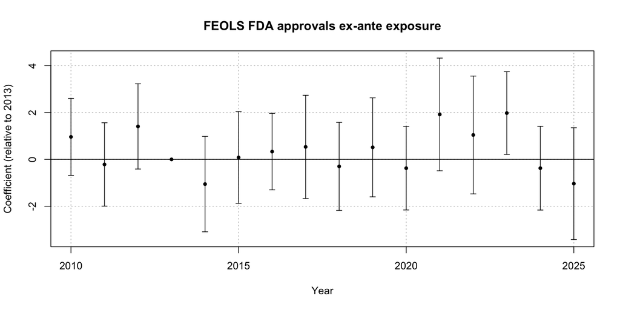

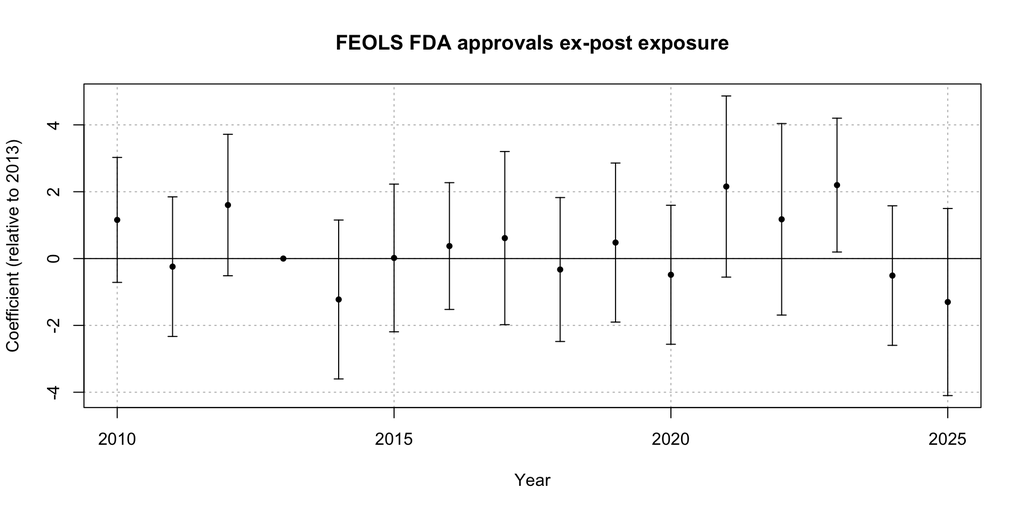

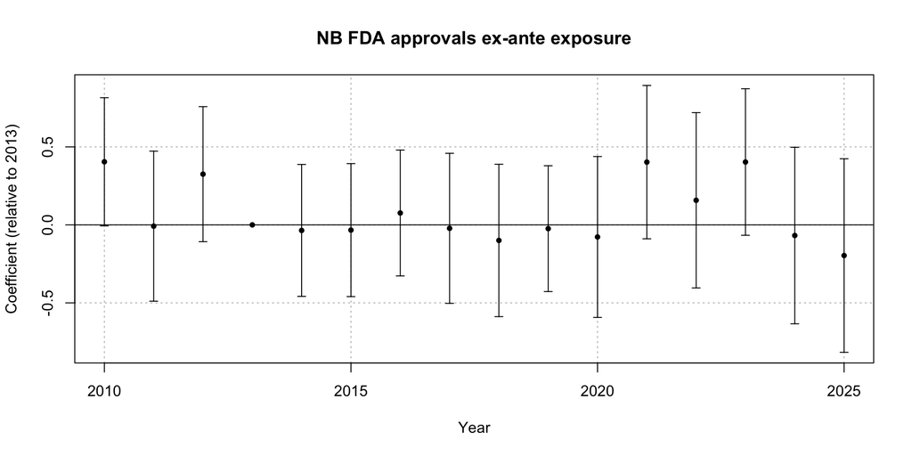

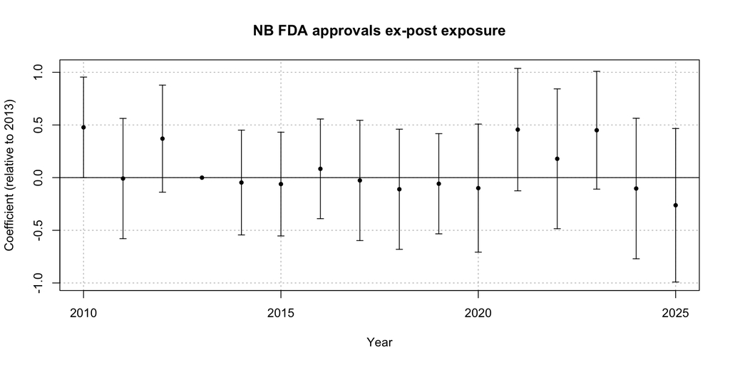

## RQ1: Patent coefficients

|  | FEOLS: Ex Ante | FEOLS: Ex Post | NB: Ex Ante | NB: Ex Post |
| --- | --- | --- | --- | --- |
| patent_year = 2010 × medicaid_market_share | 0.969 | 1.152 | 0.088 | 0.119 |
|  | (0.786) | (0.839) | (0.081) | (0.086) |
| patent_year = 2011 × medicaid_market_share | 0.831 | 0.925 | 0.152* | 0.176* |
|  | (0.647) | (0.693) | (0.067) | (0.072) |
| patent_year = 2012 × medicaid_market_share | 0.618 | 0.624 | 0.067 | 0.073 |
|  | (0.501) | (0.533) | (0.056) | (0.060) |
| patent_year = 2014 × medicaid_market_share | -0.115 | -0.084 | 0.019 | 0.033 |
|  | (0.513) | (0.537) | (0.055) | (0.059) |
| patent_year = 2015 × medicaid_market_share | -1.081 | -1.252 | 0.023 | 0.024 |
|  | (0.630) | (0.676) | (0.060) | (0.065) |
| patent_year = 2016 × medicaid_market_share | -2.148** | -2.431** | -0.035 | -0.043 |
|  | (0.731) | (0.790) | (0.065) | (0.070) |
| patent_year = 2017 × medicaid_market_share | -2.143** | -2.397** | -0.015 | -0.011 |
|  | (0.777) | (0.837) | (0.069) | (0.073) |
| patent_year = 2018 × medicaid_market_share | -2.899** | -3.200** | -0.034 | -0.023 |
|  | (0.897) | (0.973) | (0.075) | (0.080) |
| patent_year = 2019 × medicaid_market_share | -3.718*** | -4.088*** | -0.146* | -0.144 |
|  | (0.929) | (1.014) | (0.074) | (0.079) |
| patent_year = 2020 × medicaid_market_share | -4.693*** | -5.190*** | -0.310*** | -0.331*** |
|  | (1.027) | (1.122) | (0.084) | (0.090) |
| patent_year = 2021 × medicaid_market_share | -4.771*** | -5.269*** | -0.257** | -0.265** |
|  | (1.047) | (1.151) | (0.084) | (0.091) |
| patent_year = 2022 × medicaid_market_share | -5.157*** | -5.709*** | -0.303*** | -0.326*** |
|  | (1.090) | (1.191) | (0.087) | (0.094) |
| patent_year = 2023 × medicaid_market_share | -5.836*** | -6.529*** | -0.431*** | -0.478*** |
|  | (1.224) | (1.345) | (0.096) | (0.104) |
| patent_year = 2024 × medicaid_market_share | -5.780*** | -6.431*** | -0.417*** | -0.450*** |
|  | (1.237) | (1.354) | (0.102) | (0.110) |
| patent_year = 2025 × medicaid_market_share | -5.568*** | -6.211*** | -0.296* | -0.318* |
|  | (1.246) | (1.376) | (0.116) | (0.127) |
| Num.Obs. | 317419 | 317419 | 317419 | 317419 |
| R2 | 0.518 | 0.518 | 0.212 | 0.212 |
| R2 Adj. | 0.351 | 0.352 | 0.093 | 0.093 |
| R2 Within | 0.005 | 0.005 | 0.078 | 0.078 |
| R2 Within Adj. | 0.005 | 0.005 | 0.078 | 0.078 |
| AIC | 1781064.9 | 1780948.9 | 1235842.7 | 1235834.8 |
| BIC | 2648787.5 | 2648671.5 | 2103565.3 | 2103557.4 |
| RMSE | 3.10 | 3.10 | 2.92 | 2.92 |
| Std.Errors | by: firm | by: firm | by: firm | by: firm |
| FE: firm^atc_level1 | X | X | X | X |
| FE: patent_year | X | X | X | X |

* p < 0.05, ** p < 0.01, *** p < 0.001

## RQ1: Patent plots

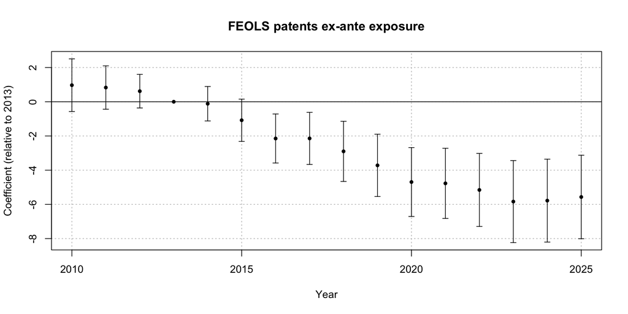

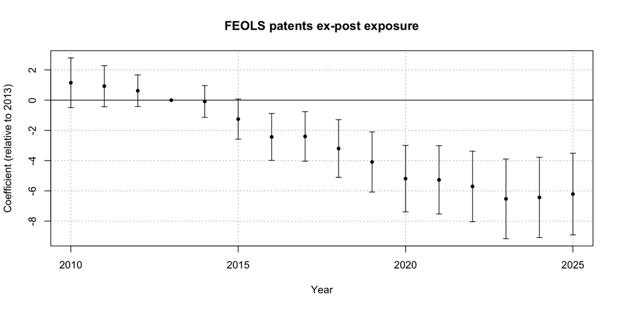

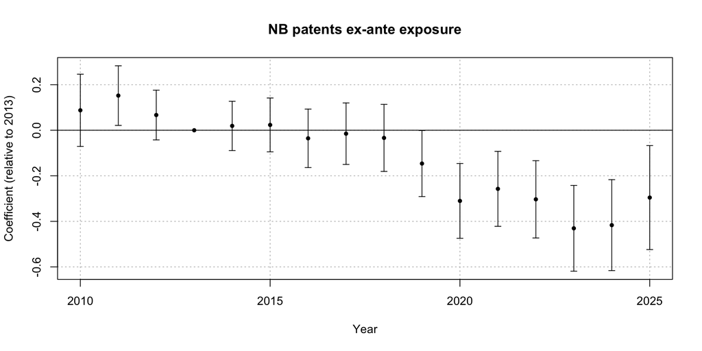

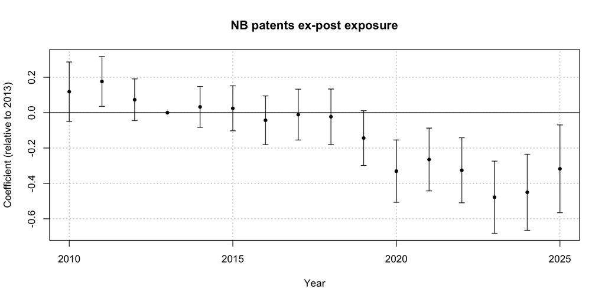

## RQ2: Market Size and Pricing Pressure

$$\begin{aligned}
Y_{f,c,t}
&= \alpha_{f,c} + \delta_t + \sum_{l \neq 2013}^{2025} \beta_{l}
\left( \text{Expansion}_{l} \times \text{MedicaidShare}_c \right) \\
&\quad + \sum_{j \neq 2013}^{2025} \gamma_{\ell}
\left( \text{Expansion}_{j} \times \text{PDL_Exposure}_{f,c} \right) + \varepsilon_{f,c,t}
\end{aligned}$$

Where:

$$\text{PDL_Exposure}_{f,c}
=
\frac{
\text{Number of drugs on PDL}_{f,c}
}{
\text{Number of drugs}_{f,c}
}$$

- $\beta$ measures market size effects
- $\gamma$ measures the effect of firms more exposed to the PDL pricing pressure
- Measuring price effects is unrealistic and therefore measuring the effect of being on the market itself is worhtwhl

## FDA coefficients

|  | FEOLS: Ex Ante | FEOLS: Ex Post |
| --- | --- | --- |
| approval_year = 2010 × medicaid_market_share | -0.056 | -0.064 |
|  | (0.644) | (0.965) |
| approval_year = 2011 × medicaid_market_share | -0.700 | -0.999 |
|  | (0.614) | (0.934) |
| approval_year = 2012 × medicaid_market_share | 0.496 | 0.451 |
|  | (0.576) | (0.851) |
| approval_year = 2014 × medicaid_market_share | -0.862 | -1.469 |
|  | (0.624) | (1.025) |
| approval_year = 2015 × medicaid_market_share | -0.719 | -1.325 |
|  | (0.465) | (0.725) |
| approval_year = 2016 × medicaid_market_share | -0.245 | -0.558 |
|  | (0.563) | (0.840) |
| approval_year = 2017 × medicaid_market_share | -0.737 | -1.125 |
|  | (0.548) | (0.854) |
| approval_year = 2018 × medicaid_market_share | -0.676 | -0.881 |
|  | (0.557) | (0.825) |
| approval_year = 2019 × medicaid_market_share | 0.082 | -0.149 |
|  | (0.636) | (0.973) |
| approval_year = 2020 × medicaid_market_share | -1.007 | -1.549 |
|  | (0.659) | (1.045) |
| approval_year = 2021 × medicaid_market_share | -0.241 | -0.536 |
|  | (0.536) | (0.836) |
| approval_year = 2022 × medicaid_market_share | -0.180 | -0.324 |
|  | (0.559) | (0.812) |
| approval_year = 2023 × medicaid_market_share | 0.274 | 0.199 |
|  | (0.660) | (1.023) |
| approval_year = 2024 × medicaid_market_share | -0.838 | -1.275 |
|  | (0.590) | (0.875) |
| approval_year = 2025 × medicaid_market_share | -1.200 | -2.003 |
|  | (0.878) | (1.458) |
| approval_year = 2010 × in_pdl | 0.111 | 0.122 |
|  | (0.429) | (0.431) |
| approval_year = 2011 × in_pdl | 0.070 | 0.077 |
|  | (0.299) | (0.302) |
| approval_year = 2012 × in_pdl | 0.634 | 0.647 |
|  | (0.407) | (0.406) |
| approval_year = 2014 × in_pdl | 0.672 | 0.688 |
|  | (0.416) | (0.424) |
| approval_year = 2015 × in_pdl | -0.191 | -0.183 |
|  | (0.337) | (0.339) |
| approval_year = 2016 × in_pdl | -0.109 | -0.100 |
|  | (0.218) | (0.221) |
| approval_year = 2017 × in_pdl | 0.065 | 0.069 |
|  | (0.260) | (0.263) |
| approval_year = 2018 × in_pdl | 0.251 | 0.254 |
|  | (0.290) | (0.291) |
| approval_year = 2019 × in_pdl | 0.367 | 0.367 |
|  | (0.337) | (0.342) |
| approval_year = 2020 × in_pdl | 0.321 | 0.315 |
|  | (0.397) | (0.398) |
| approval_year = 2021 × in_pdl | 0.437 | 0.438 |
|  | (0.241) | (0.243) |
| approval_year = 2022 × in_pdl | 0.086 | 0.091 |
|  | (0.292) | (0.291) |
| approval_year = 2023 × in_pdl | 0.412 | 0.396 |
|  | (0.635) | (0.639) |
| approval_year = 2024 × in_pdl | -0.546 | -0.544 |
|  | (0.338) | (0.338) |
| Num.Obs. | 48303 | 48303 |
| R2 | 0.229 | 0.229 |
| R2 Adj. | 0.184 | 0.184 |
| R2 Within | 0.004 | 0.004 |
| R2 Within Adj. | 0.003 | 0.003 |
| AIC | 169019.8 | 169020.7 |
| BIC | 192564.3 | 192565.2 |
| RMSE | 1.32 | 1.32 |
| Std.Errors | by: firm | by: firm |
| FE: firm^atc_level1 | X | X |
| FE: approval_year | X | X |

* p < 0.05, ** p < 0.01, *** p < 0.001

## FDA plots

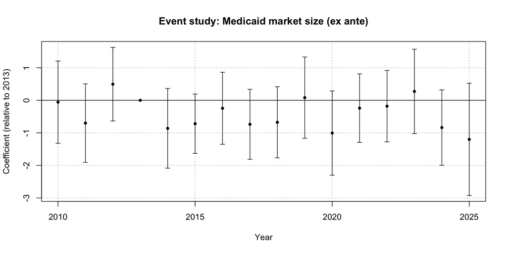

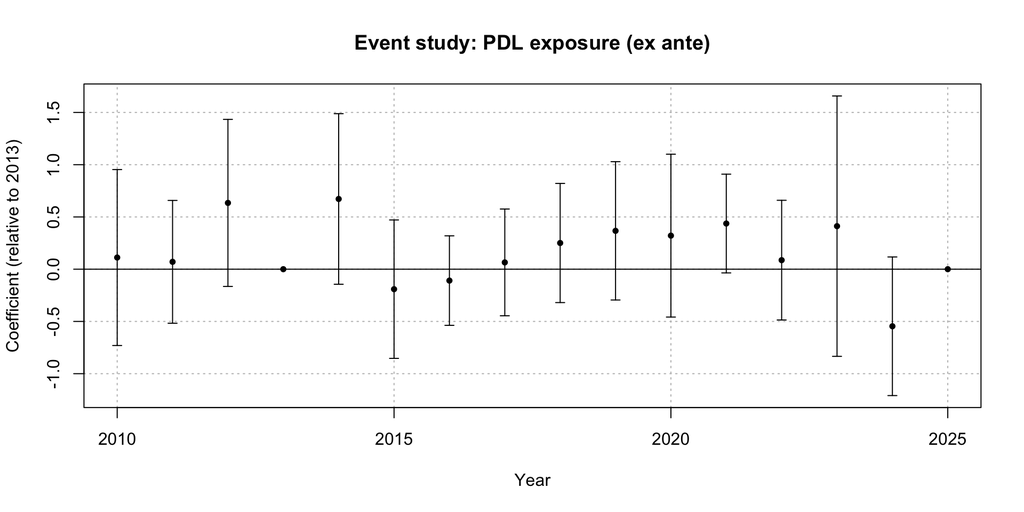

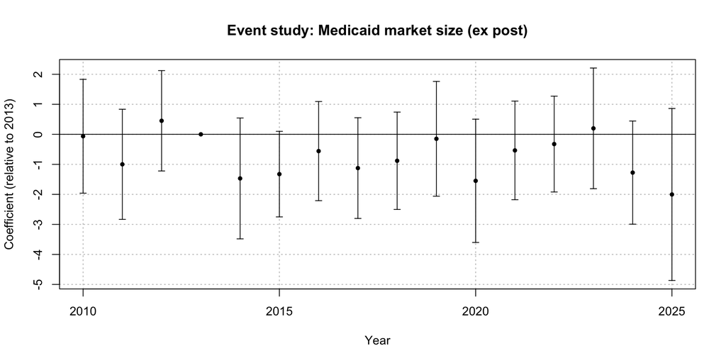

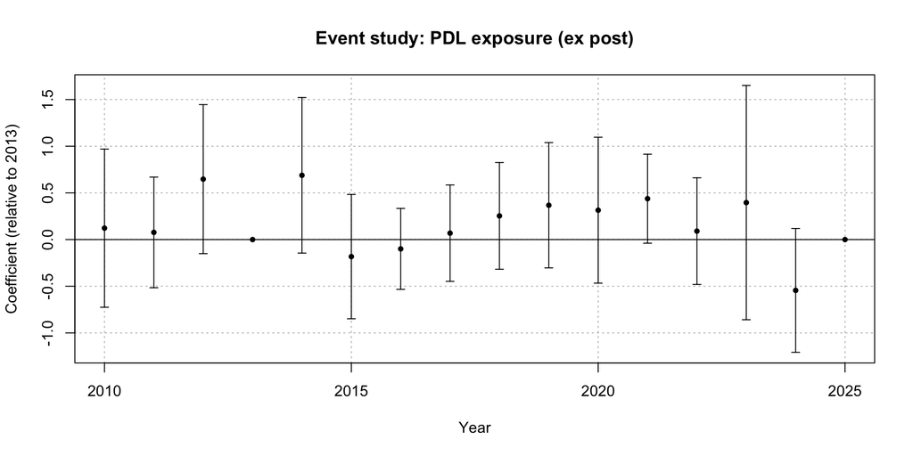

## Patent coefficients

|  | FEOLS: Ex Ante | FEOLS: Ex Post |
| --- | --- | --- |
| patent_year = 2010 × medicaid_market_share | 1.091 | 1.487 |
|  | (0.929) | (0.991) |
| patent_year = 2011 × medicaid_market_share | 0.780 | 0.981 |
|  | (0.808) | (0.865) |
| patent_year = 2012 × medicaid_market_share | 0.491 | 0.478 |
|  | (0.646) | (0.686) |
| patent_year = 2014 × medicaid_market_share | -0.303 | -0.181 |
|  | (0.605) | (0.623) |
| patent_year = 2015 × medicaid_market_share | -1.773* | -2.076* |
|  | (0.781) | (0.834) |
| patent_year = 2016 × medicaid_market_share | -3.212*** | -3.694*** |
|  | (0.946) | (1.026) |
| patent_year = 2017 × medicaid_market_share | -3.277** | -3.718*** |
|  | (1.018) | (1.102) |
| patent_year = 2018 × medicaid_market_share | -3.933*** | -4.391*** |
|  | (1.167) | (1.277) |
| patent_year = 2019 × medicaid_market_share | -5.131*** | -5.706*** |
|  | (1.224) | (1.356) |
| patent_year = 2020 × medicaid_market_share | -6.303*** | -7.061*** |
|  | (1.363) | (1.508) |
| patent_year = 2021 × medicaid_market_share | -6.411*** | -7.184*** |
|  | (1.403) | (1.572) |
| patent_year = 2022 × medicaid_market_share | -6.888*** | -7.694*** |
|  | (1.470) | (1.616) |
| patent_year = 2023 × medicaid_market_share | -7.846*** | -8.929*** |
|  | (1.674) | (1.864) |
| patent_year = 2024 × medicaid_market_share | -7.860*** | -8.835*** |
|  | (1.656) | (1.831) |
| patent_year = 2025 × medicaid_market_share | -7.428*** | -8.422*** |
|  | (1.702) | (1.914) |
| patent_year = 2010 × in_pdl | 5.238 | 5.233 |
|  | (2.684) | (2.680) |
| patent_year = 2011 × in_pdl | 2.551 | 2.536 |
|  | (1.583) | (1.579) |
| patent_year = 2012 × in_pdl | 1.889 | 1.881 |
|  | (1.058) | (1.058) |
| patent_year = 2014 × in_pdl | 3.709* | 3.700* |
|  | (1.606) | (1.606) |
| patent_year = 2015 × in_pdl | 0.244 | 0.234 |
|  | (1.283) | (1.281) |
| patent_year = 2016 × in_pdl | -1.758 | -1.774 |
|  | (1.548) | (1.547) |
| patent_year = 2017 × in_pdl | -1.459 | -1.475 |
|  | (1.988) | (1.987) |
| patent_year = 2018 × in_pdl | -2.892 | -2.915 |
|  | (1.715) | (1.716) |
| patent_year = 2019 × in_pdl | -4.449 | -4.473 |
|  | (2.405) | (2.407) |
| patent_year = 2020 × in_pdl | -5.955* | -5.990* |
|  | (2.537) | (2.539) |
| patent_year = 2021 × in_pdl | -6.148** | -6.186** |
|  | (2.129) | (2.134) |
| patent_year = 2022 × in_pdl | -7.361* | -7.384* |
|  | (2.878) | (2.882) |
| patent_year = 2023 × in_pdl | -9.829*** | -9.875*** |
|  | (2.675) | (2.682) |
| patent_year = 2024 × in_pdl | -8.317*** | -8.369*** |
|  | (2.517) | (2.522) |
| Num.Obs. | 317419 | 317419 |
| R2 | 0.521 | 0.521 |
| R2 Adj. | 0.356 | 0.356 |
| R2 Within | 0.012 | 0.012 |
| R2 Within Adj. | 0.012 | 0.012 |
| AIC | 1778795.4 | 1778720.6 |
| BIC | 2646667.4 | 2646592.6 |
| RMSE | 3.09 | 3.09 |
| Std.Errors | by: firm | by: firm |
| FE: firm^atc_level1 | X | X |
| FE: patent_year | X | X |

* p < 0.05, ** p < 0.01, *** p < 0.001

## Patent plots

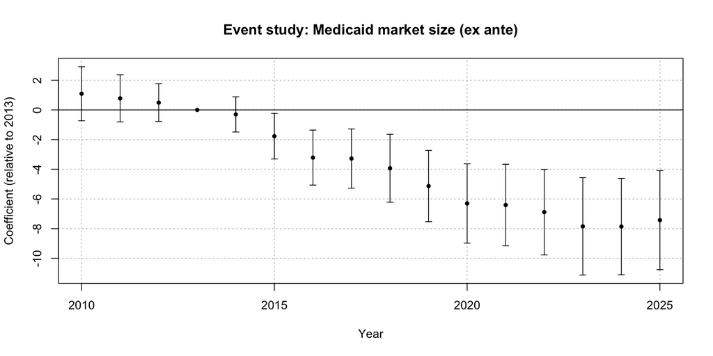

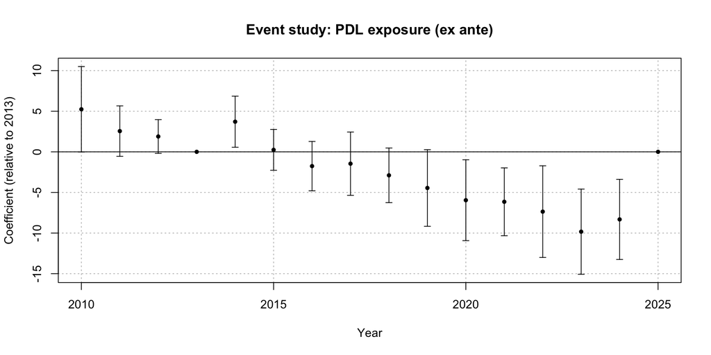

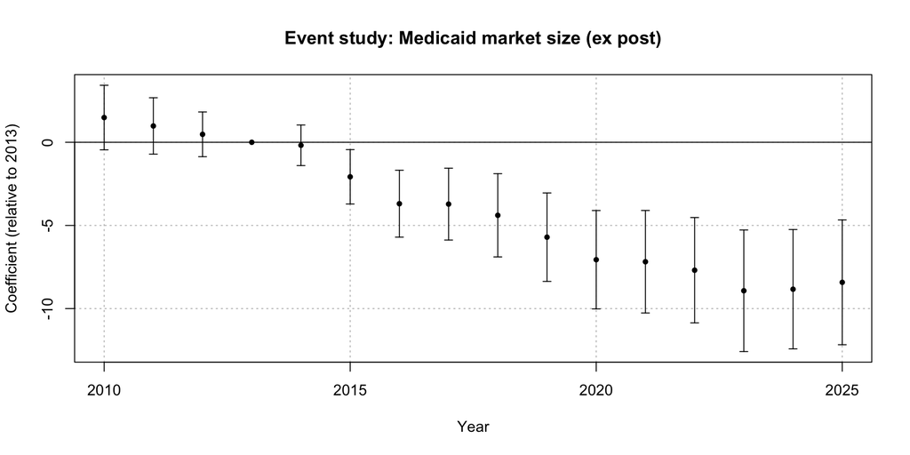

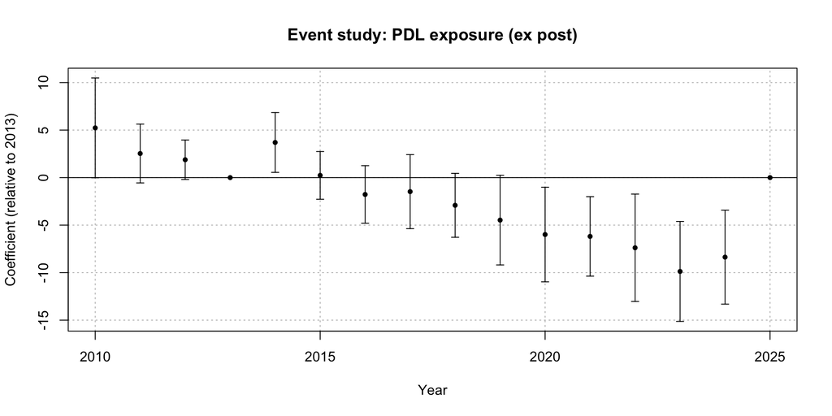

## RQ3: Innovation portfolio

**Old issue:**

Share of innovation variable is polluted by averaging changes in share of innovation across all therapeutic areas. However, a reduction in the share of innovation for therapeutic area A by firm X would also mean that the firm faces an increases in other areas. Current DiD specification cannot isolate these effects .

**Fixes**

1. Change variable from share of innovation to a count of innovation - avoids spillovers effect of an increase in share A leading to a decrease in share B.
2. Introduce triple difference to isolate effects of each therapeutic class.

$$\begin{aligned}
\begin{aligned}
Y_{f,c,t}
&= \alpha_f + \lambda_c + \delta_t \\
&\quad + \sum_{c \in \mathcal{C}}
\beta_c
\Big(
\mathbb{1}\{t \geq 2014\}
\times \text{MedicaidShare}_c
\times \mathbb{1}\{\text{ATC} = c\}
\Big)
+ \varepsilon_{f,c,t}.
\end{aligned}
\end{aligned}$$

## FDA coefficients

|  | FEOLS: Ex Ante | FEOLS: Ex Post |
| --- | --- | --- |
| medicaid_market_share × post × atc_level1 = A | -0.805 | -0.528 |
|  | (3.714) | (2.437) |
| medicaid_market_share × post × atc_level1 = B | 21.897 | 6.513 |
|  | (68.834) | (20.473) |
| medicaid_market_share × post × atc_level1 = C | -2.518 | -3.135 |
|  | (1.839) | (2.289) |
| medicaid_market_share × post × atc_level1 = D | -1.684 | -2.289 |
|  | (3.419) | (4.648) |
| medicaid_market_share × post × atc_level1 = G | -7.961 | -3.695 |
|  | (38.192) | (17.728) |
| medicaid_market_share × post × atc_level1 = H | 14.777 | 5.971 |
|  | (35.952) | (14.526) |
| medicaid_market_share × post × atc_level1 = J | -6.017* | -3.074* |
|  | (2.763) | (1.412) |
| medicaid_market_share × post × atc_level1 = L | 34.296 | 32.271 |
|  | (46.543) | (43.794) |
| medicaid_market_share × post × atc_level1 = M | -9.595 | -5.999 |
|  | (23.374) | (14.612) |
| medicaid_market_share × post × atc_level1 = N | -0.399 | -0.561 |
|  | (0.477) | (0.670) |
| medicaid_market_share × post × atc_level1 = P | -340.511 | -278.513 |
|  | (1930.299) | (1578.842) |
| medicaid_market_share × post × atc_level1 = R | -1.856 | -1.013 |
|  | (3.017) | (1.646) |
| medicaid_market_share × post × atc_level1 = S | -53.576 | -40.907 |
|  | (69.374) | (52.969) |
| Num.Obs. | 48303 | 48303 |
| R2 | 0.163 | 0.163 |
| R2 Adj. | 0.151 | 0.151 |
| R2 Within | 0.002 | 0.002 |
| R2 Within Adj. | 0.002 | 0.002 |
| AIC | 169017.2 | 169017.2 |
| BIC | 175096.6 | 175096.6 |
| RMSE | 1.37 | 1.37 |
| Std.Errors | by: firm | by: firm |
| FE: firm | X | X |
| FE: atc_level1 | X | X |
| FE: approval_year | X | X |

* p < 0.05, ** p < 0.01, *** p < 0.001

## Patent coefficients

|  | FEOLS: Ex Ante | FEOLS: Ex Post |
| --- | --- | --- |
| medicaid_market_share × post × atc_level1 = A | -9.439 | -6.817 |
|  | (4181.113) | (2929.981) |
| medicaid_market_share × post × atc_level1 = B | -10.492 | -7.700 |
|  | (18354.825) | (13660.227) |
| medicaid_market_share × post × atc_level1 = C | -16.245 | -14.899 |
|  | (8952.153) | (7994.858) |
| medicaid_market_share × post × atc_level1 = D | -86.053 | -67.528 |
|  | (70949.176) | (54709.078) |
| medicaid_market_share × post × atc_level1 = G | -44.239 | -41.782 |
|  | (32029.853) | (29625.798) |
| medicaid_market_share × post × atc_level1 = H | -35.170 | -24.684 |
|  | (81044.515) | (58813.212) |
| medicaid_market_share × post × atc_level1 = J | -16.878 | -10.733 |
|  | (19511.345) | (12329.790) |
| medicaid_market_share × post × atc_level1 = L | -52.449 | -63.999 |
|  | (42523.372) | (50962.888) |
| medicaid_market_share × post × atc_level1 = M | -51.468 | -31.998 |
|  | (28833.762) | (17460.319) |
| medicaid_market_share × post × atc_level1 = N | -6.910 | -8.357 |
|  | (2126.175) | (2483.959) |
| medicaid_market_share × post × atc_level1 = P | 118.538 | 171.778 |
|  | (1463274.248) | (1445153.841) |
| medicaid_market_share × post × atc_level1 = R | -3.456 | -3.971 |
|  | (2474.173) | (2783.668) |
| medicaid_market_share × post × atc_level1 = S | -7.634 | -8.796 |
|  | (11376.197) | (13175.865) |
| medicaid_market_share × post × atc_level1 = V | -285.458 | -220.156 |
|  | (304320.771) | (232514.185) |
| Num.Obs. | 317419 | 317419 |
| R2 | 0.325 | 0.325 |
| R2 Adj. | 0.276 | 0.276 |
| R2 Within | 0.003 | 0.003 |
| R2 Within Adj. | 0.003 | 0.003 |
| AIC | 1768104.0 | 1768104.0 |
| BIC | 1999236.4 | 1999236.4 |
| RMSE | 3.66 | 3.66 |
| Std.Errors | by: firm | by: firm |
| FE: firm | X | X |
| FE: atc_level1 | X | X |
| FE: patent_year | X | X |

* p < 0.05, ** p < 0.01, *** p < 0.001

# Appendix

## Available Data

A large issue with cleaning the data comes from cleaning the datasrets in such a way they can be mapped to the Medicaid SDUD dataset.

This involves mapping each of the datasets to a therapeutic area, as well as finding a method to match firms since firms aren’t even mentioned in the SDUD data. - Standard cleaning and fuzzy matching did not work !

| Outcome Data | Stage in innovation pipeline | Processed |
| --- | --- | --- |
| Patents | early stage | ✅ |
| Clinical trials | mid stage | ❌ |
| Drug Approvals | end stage | ✅ |

## Medicaid State Drug Utilisation Data

| Variable | Info |
| --- | --- |
| NDC | 11 digit code uniquely identifying drugs, their firm and the package sizing. This is split into three variables: **labeler code** (firm);**product code** (drug for said firm); **package size** |
| Drug name | Name of the drug |
| Units reimbursed | Number of units paid for by Medicaid during the Year-Q |
| Number of prescriptions | Count of prescriptions for a given drug in in that state and Year-Q |
| Reimbursement amount | Tells us the total amount paid for a given drug in that state and Year-Q. This is split into three variables: total, medicaid and non-medicaid. |

Most firms have multiple NDC labeler codes so matching on labeler code is insufficient and further cleaning was required.

## Aggregation

Aggregated at broad therapeutic level. - ATC level 1: main anatonmical groups - ATC level 2: further refines each level1 cat into a therapeutic subgroup e.g. diabetes, antibacterials, beta-blockers

| ATC Code | Therapeutic Area |
| --- | --- |
| A | Alimentary tract and metabolism |
| B | Blood and blood-forming organs |
| C | Cardiovascular system |
| D | Dermatologicals |
| G | Genito-urinary system and sex hormones |
| H | Systemic hormonal preparations |
| J | Anti-infectives for systemic use |
| L | Antineoplastic and immunomodulating agents |
| M | Musculo-skeletal system |
| N | Nervous system |
| P | Antiparasitic products, insecticides and repellents |
| R | Respiratory system |
| S | Sensory organs |
| V | Various |

## Collapsing SDUD

After cleaning Medicaid SDUD data it’s collapsed to obtain the number of prescriptions and reimbursement amounts. This is used to build demand proxies for a given therapeutic area.

```r
# Collapse SDUD data to firm-year-quarter-ATC level

SDUD_firm_ATC <- SDUD_firm_mapped |>
  group_by(
    state,
    firm,
    labeler_code,
    year,
    quarter,
    ATC_Level1,
    ATC_Level2
  ) |>
  summarise(
    prescriptions = sum(number_of_prescriptions, na.rm = TRUE),
    medicaid_reimbursed = sum(medicaid_amount_reimbursed, na.rm = TRUE),
    non_medicaid_reimbursed = sum(non_medicaid_amount_reimbursed, na.rm = TRUE),
    .groups = "drop"
  )

# SDUD ATC level 1 aggregate indicators

SDUD_ATC1 <- SDUD_firm_ATC |>
  group_by(year, quarter, ATC_Level1) |>
  summarise(
    ATC1_prescriptions = sum(prescriptions, na.rm = TRUE),
    ATC1_medicaid_reimbursed = sum(medicaid_reimbursed, na.rm = TRUE),
    ATC1_non_medicaid_reimbursed = sum(non_medicaid_reimbursed, na.rm = TRUE),
    .groups = "drop"
  )

# SDUD ATC level 2 aggregate indicators

SDUD_ATC2 <- SDUD_firm_ATC |>
  group_by(year, quarter, ATC_Level2) |>
  summarise(
    ATC2_prescriptions = sum(prescriptions, na.rm = TRUE),
    ATC2_medicaid_reimbursed = sum(medicaid_reimbursed, na.rm = TRUE),
    ATC2_non_medicaid_reimbursed = sum(non_medicaid_reimbursed, na.rm = TRUE),
    .groups = "drop"
  )
```

## Collapsing Patents

```r
pharma_patents_collapsed <- pharma_patents_full |>
  filter(patent_year >= 2005) |>
  group_by(
    ndc_firm_id,
    firm,
    patent_year,
    patent_quarter,
    ATC1
  ) |>
  summarise(
    num_patents = n(),
    .groups = "drop"
  )
```

## Collapsing Drug approvals

```r
fda_approvals_panel <- fda_atc_expanded |>
  group_by(
    sponsor_name,
    labeler_code,
    approval_year,
    approval_quarter,
    atc_level1,
    atc_level2
  ) |>
  summarise(
    n_approvals = n(),
    .groups = "drop"
  )
```